# Experiment 1 - cattail seedling growth in a common garden experiment

### Plant height

```r
Form <- formula(log(Ht) ~ Species * Shade * Leachate)

MH1.0 <- lme(Form, random = ~1|Pond, method = "ML", data=TEx1)
MH1.1 <- update(MH1.0, .~. - Species:Shade:Leachate) # test to see whether we can drop the third-order interaction
anova(MH1.0, MH1.1) #test that the 3-order interaction is not significant (it's not)
```

```
##       Model df      AIC      BIC    logLik   Test  L.Ratio p-value
## MH1.0     1 14 543.1928 594.4743 -257.5964
## MH1.1     2 12 540.0290 583.9846 -258.0145 1 vs 2 0.836196  0.6583
```

```r
Form2 <- formula(log(Ht) ~ Species * Shade + Species * Leachate + Shade * Leachate)
MH2.0 <- lme(Form2, random = ~1|Pond, data=TEx1, method = "ML")
MH2.1 <- update(MH2.0, .~. -Species:Shade)
MH2.2 <- update(MH2.0, .~. -Species:Leachate) #drop this one
MH2.3 <- update(MH2.0, .~. -Shade:Leachate)

Form3 <- formula(log(Ht) ~ Species * Shade + Shade * Leachate)
MH3.0 <- lme(Form3, random = ~1|Pond, data = TEx1, method = "ML")
MH3.1 <- update(MH3.0, .~. -Species:Shade)
MH3.2 <- update(MH3.0, .~. -Shade:Leachate) #drop this one

Form4 <- formula(log(Ht) ~ Species * Shade + Leachate)
MH4.0 <- lme(Form4, random = ~1|Pond, data = TEx1, method = "ML")
MH4.1 <- update(MH4.0, .~. -Species:Shade)

Form5 <- formula(log(Ht) ~ Species + Shade + Leachate)
MH5.0 <- lme(Form5, random = ~1|Pond, data = TEx1, method = "ML")
MH5.1 <- update(MH5.0, .~. -Species)
MH5.2 <- update(MH5.0, .~. -Shade) #drop this one
MH5.3 <- update(MH5.0, .~. -Leachate)

Form6 <- formula(log(Ht) ~ Species + Leachate)
MH6.0 <- lme(Form6, random = ~1|Pond, data = TEx1, method = "ML")
MH6.1 <- update(MH6.0, .~. -Species)
MH6.2 <- update(MH6.0, .~. -Leachate) #drop this one

Form7 <- formula(log(Ht) ~ Species)
MH7.0 <- lme(Form7, random = ~1|Pond, data = TEx1, method = "ML")
MH7.1 <- update(MH7.0, .~. -Species)
anova(MH7.0, MH7.1)
```

```
##       Model df      AIC      BIC    logLik   Test  L.Ratio p-value
## MH7.0     1  5 531.2663 549.5811 -260.6331
## MH7.1     2  3 533.3475 544.3364 -263.6737 1 vs 2 6.081228  0.0478
```

```r
MH4.final <- lme(Form5, random = ~1|Pond, data = TEx1, method = "REML")
```

```r
summary(MH4.final)
```

```
## Linear mixed-effects model fit by REML
##  Data: TEx1
##        AIC      BIC    logLik
##   545.9946 571.5128 -265.9973
##
## Random effects:
##  Formula: ~1 | Pond
##         (Intercept)  Residual
## StdDev:   0.4334024 0.5562093
##
## Fixed effects: list(Form5)
##                 Value  Std.Error  DF   t-value p-value
## (Intercept)  4.290459 0.18393102 266 23.326457  0.0000
## SpeciesG     0.201092 0.08151513 266  2.466927  0.0143
## SpeciesL     0.101111 0.07990995 266  1.265315  0.2069
## ShadeYS     -0.085158 0.20466092  17 -0.416095  0.6825
## LeachateYL  -0.228985 0.20466178  17 -1.118848  0.2788
##  Correlation:
##            (Intr) SpecsG SpecsL ShadYS
## SpeciesG   -0.225
## SpeciesL   -0.232  0.509
## ShadeYS    -0.558  0.005  0.005
## LeachateYL -0.559  0.002  0.005  0.000
##
## Standardized Within-Group Residuals:
##        Min         Q1        Med         Q3        Max
## -4.2492491 -0.3747924  0.1828203  0.5751534  2.1327694
##
## Number of Observations: 288
## Number of Groups: 20
```

```r
Anova(MH4.final, Type = "III")
```

```
## Analysis of Deviance Table (Type II tests)
##
## Response: log(Ht)
##           Chisq Df Pr(>Chisq)
## Species  6.0859  2    0.04769 *
## Shade    0.1731  1    0.67734
## Leachate 1.2518  1    0.26321
## ---
## Signif. codes:  0 '***' 0.001 '**' 0.01 '*' 0.05 '.' 0.1 ' ' 1
```

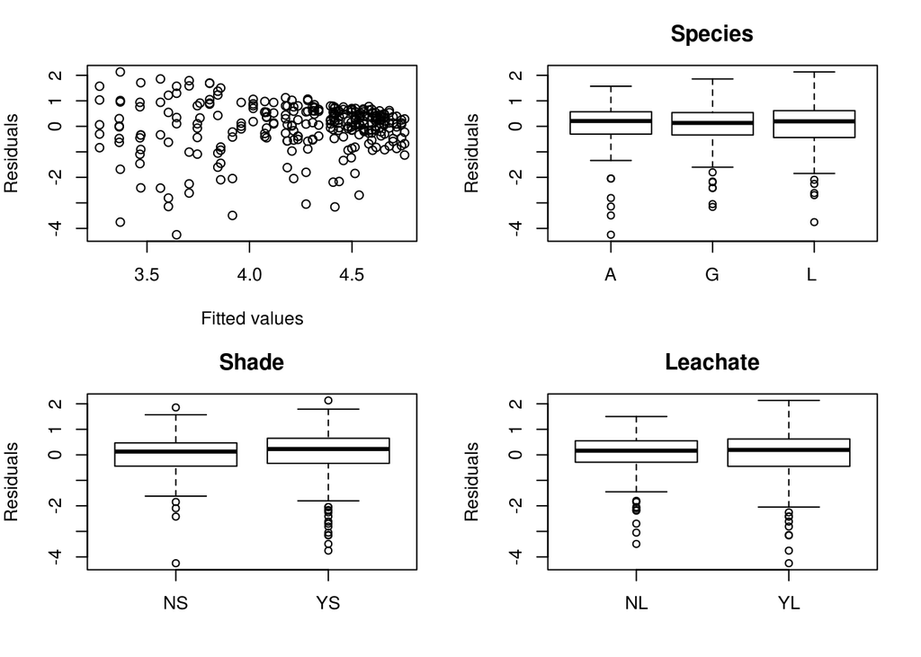

```r
#the next step is model validation
op <- par(mfrow=c(2,2), mar=c(4,4,3,2))
EH4 <- resid(MH4.final, type = "normalized")
FH4 <- fitted(MH4.final)
plot(FH4, EH4, xlab = "Fitted values", ylab = MyYlab)
boxplot(EH4 ~ Species, data = TEx1, main = "Species", ylab = MyYlab)
boxplot(EH4 ~ Shade, data = TEx1, main = "Shade", ylab = MyYlab)
boxplot(EH4 ~ Leachate, data = TEx1, main = "Leachate", ylab = MyYlab)
```

The next step is to plot the result using boxplots.

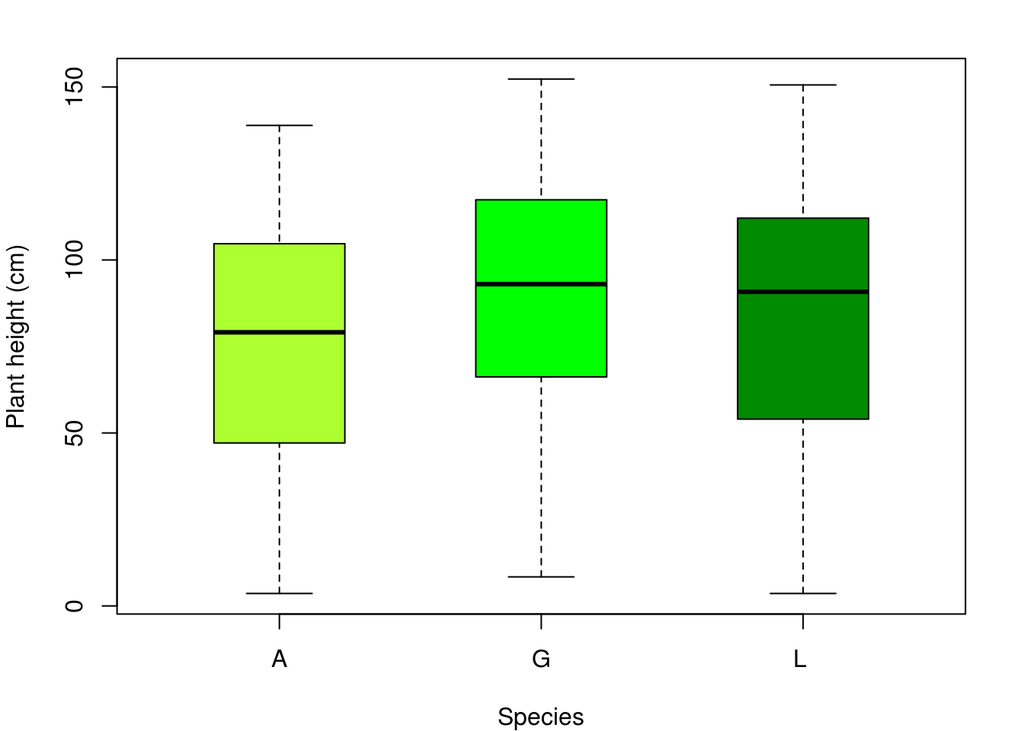

```r
par(op)
par(mfrow=c(1,1), mar=c(4,4,2,2))
boxplot(Ht ~ Species, data=TEx1, boxwex=0.5,
        col=c("greenyellow", "green", "green4"),
        xlab="Species",
        ylab = "Plant height (cm)")
```

### Main Results

- There was little evidence for an effect of leachate on established plants.
- The only consistently significant effect on the measures of plant size was the species effect
- *Typha latifolia* and *T. x glauca* tended to outperform *T. angustifolia*
- *Typha latifolia* tended to respond differently to the shade treatment than the other species
- *T. latifolia* appeared to tolerate the shade; while plants of the other species got smaller depending on the measure used it tended to remain the same size (N ramets) or even get bigger (above-ground biomass)